# Loading and preprocessing the data

## Loading and preprocessing the data

1. First, library the three packages that would be used in this project: ggplot2, dplyr and scales.
2. Read the data and save it into rawds. Transform the data type of column date into Date class.
3. Finally add a new column on the right-most of the table called Weekdays, indicating the weekday of the date. This column will become crucial later.

## What is mean total number of steps taken per day?

```r
group_by(rawds,date) %>% summarise('TotalSteps'=sum(steps))->dds
```

1. Devide rawds into groups according to dates.
2. Sum up the steps for each day, and save it into a new table dds.

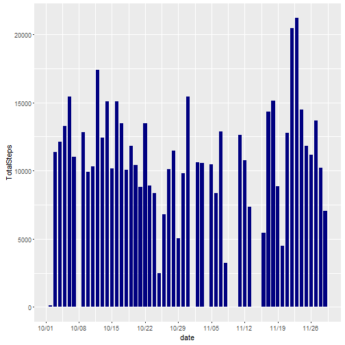

[figure not shown]

**Calculate the mean and median over all observations**

```r
mean(dds$TotalSteps,na.rm=T)
```

```
## [1] 10766.19
```

```r
median(dds$TotalSteps,na.rm=T)
```

```
## [1] 10765
```

As calculated above, the mean is 10766.19 and the median is 10765.

## What is the average daily activity pattern?

**The code to process data:**

```r
group_by(rawds,interval)->ids
summarise(ids,'AvgSteps'=mean(steps,na.rm=T))->ids
```

1. First, devide rawds into groups according to intervals (so there will be 60*24/5=288 groups).
2. Then calculate the average steps and save it in ids.

**The time series plot of the five-minute intervals**

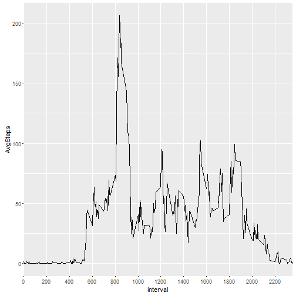

[figure not shown]

```r
q<-ggplot(ids,aes(x=interval,y=AvgSteps))+
        geom_line()+
        scale_x_discrete(breaks=seq(from=0,by=200,to =2355))
q
```

**The code to find the interval with the most steps:**

```r
ids[which.max(ids$AvgSteps),1]
```

```
## Source: local data frame [1 x 1]
##
##   interval
##      (int)
## 1      835
```

On average, the interval with most steps is 835, which is 8:35 a.m..

## Imputing missing values

**Code for finding the number of total NAs and their distributions:**

```r
sum(is.na(rawds$steps))
```

```
## [1] 2304
```

```r
rawds[is.na(rawds$steps),]->temp
table(temp$date)[table(temp$date)!=0]->temp
```

There are 2304 NAs. 2012-10-01, 2012-10-08, 2012-11-01, 2012-11-04, 2012-11-09, 2012-11-10, 2012-11-14 and 2012-11-30 equally have 288 NAs respectively. This shows that if a NA appears on any interval of a day, then other intervals will be NAs, too.

```r
group_by(rawds,Weekdays,interval)->avg.wids
summarize(avg.wids,'AvgSteps'=mean(steps,na.rm=T))->avg.wids
rawds->rawds2
for (i in 1:nrow(rawds2)){
        if (is.na(rawds2[i,])){
                rawds2[i,1]<-filter(avg.wids,Weekdays==rawds2$Weekdays[i] & interval==rawds2$interval[i])$AvgSteps[1]
        }
}
```

[output not shown]

[output not shown]

1. The avg.wids serves like a index here, recording the average steps on every weekday
2. Copy rawds to rawds2
3. Replace all NAs in the raw data with information in avg.wids.

**Code for calculating the average after replacing all NAs and its plot:**

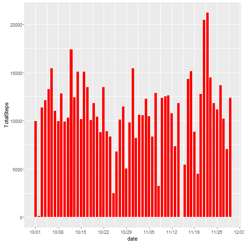

[figure not shown]

```r
group_by(rawds2,date) %>% summarise('TotalSteps'=sum(steps))->dds2
r<-ggplot(dds2,aes(x=date,y=TotalSteps))+
        geom_bar(stat="identity",fill="red",width=0.75)+
        scale_x_date(labels = date_format('%m/%d'),date_breaks = "1 week")
r
```

**Code for calculating the mean and median:**

```r
mean(dds2$TotalSteps,na.rm=T)
```

```
## [1] 10821.21
```

```r
median(dds2$TotalSteps,na.rm=T)
```

```
## [1] 11015
```

As calculated above, the mean is 10821.21 and the median is 11015. The average after filling the NAs grows higher than before.

## Are there differences in activity patterns between weekdays and weekends?